# Trabalho de Séries Temporais

Geovani Reolon ; Gabriel Alvaro ; Pedro Cabrini

2023-05-29

```r
# Carregar bibliotecas
library(ggfortify)
library(fpp3)
```

```r
library(dygraphs)
library(tsibble)
library(zoo)
library(rugarch)
```

Neste trabalho, coletamos e analisamos dados da ação MSFT (Microsoft) entre o período de 2007 até 2023, esses foram extraídos usando o pacote quantmod do R. A seguir, apresentamos uma análise do conjunto de dados, ajuste do modelo e análise de resíduos.

## Análise Exploratória de Dados

Sabemos que é melhor trabalhar com os retornos do que os preços de um ativo financeiro, para estabilizar a variâncias dos dados e evitar comportamentos de tendência não determinística. Então, utilizamos os retornos diários através do preço de fechamento da ação na data.

```r
microsoft_df = quantmod::getSymbols("MSFT", src = "yahoo", auto.assign = FALSE,
                                    from = '2007-01-01', return.class = 'zoo')# Coletando os dados
```

```r
microsoft = microsoft_df[,6] # Selecionando preços
microsoft_retorno = diff(microsoft)

dygraphs::dygraph(microsoft, ylab = "Preços ajustados", xlab = "Tempo", main = "Série temporal do histórico de preços ajustados") # Preços diários
```

[interactive chart not shown]

```r
dygraphs::dygraph(microsoft_retorno, ylab = "Retornos diários", xlab = "Tempo", main = "Série Temporal dos retornos diários") # Retornos diários
```

[interactive chart not shown]

Entretanto, vendo seu gráfico temporal, decidimos optar pelo log retorno dos preços de fechamento, afim de estabilizar mais a variância da série e garantir estacionariedade. Assim, analisando o retorno do log do preço de fechamento, tirando alguns pontos extremos, temos que a série aparenta ter média e variância constante.

```r
log_retorno_dif = diff(log(microsoft))
dygraphs::dygraph(log_retorno_dif, ylab = "Retornos diários (Log)", xlab = "Tempo", main = "Série Temporal dos retornos diários do Log") # Retornos diários Log
```

[interactive chart not shown]

Pelas estastíticas sumárias, temos que a média está bem próximo de 0. Além disso, verificando a autocorrelação, temos que grande parte se encontra dentro das bandas de confiança, porém vemos que o lag 1 ultrpassa consideravelmente a banda, o que não é um bom indicativo. Por outro lado, analisando a autocorrelação parcial, econtramos um cenário parecido, onde grande parte está dentro das bandas de confiança, exceto por alguns lags. Nesse cenário, a FACP sugere um modelo AR(2) enquanto a FAC sugere um modelo MA(1), então vamos analisar as possíves combinações para encontrar o melhor modelo.

```r
summary(log_retorno_dif)
```

```
##      Index            log_retorno_dif
##  Min.   :2007-01-04   Min.   :-0.1594535
##  1st Qu.:2011-02-11   1st Qu.:-0.0076416
##  Median :2015-03-26   Median : 0.0005190
##  Mean   :2015-03-26   Mean   : 0.0006679
##  3rd Qu.:2019-05-07   3rd Qu.: 0.0094800
##  Max.   :2023-06-16   Max.   : 0.1706257
```

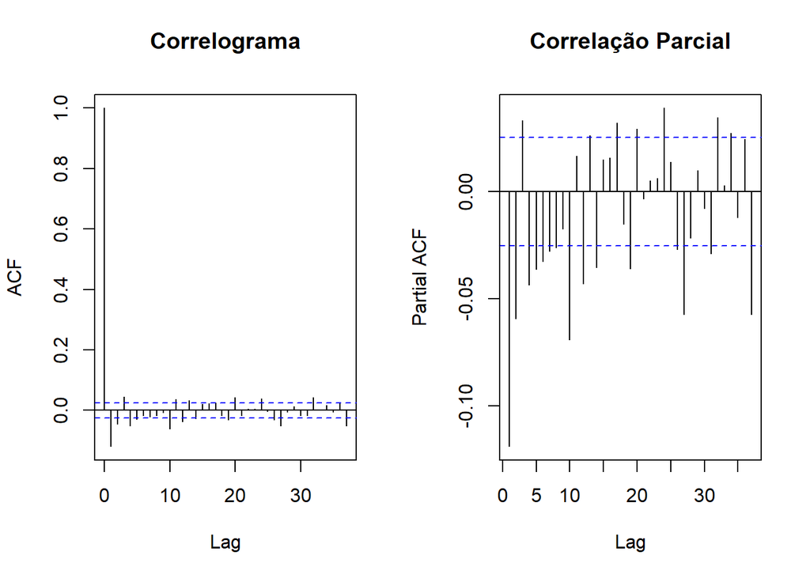

```r
op = par(mfrow = c(1, 2))
acf(log_retorno_dif, main = "Correlograma", na.action = na.pass)
pacf(log_retorno_dif, main = "Correlação Parcial", na.action = na.pass)
```

```r
par(op)
```

```r
Box.test(log_retorno_dif, type = "Ljung-Box", lag = 10)
```

```
##
##  Box-Ljung test
##
## data:  log_retorno_dif
## X-squared = 108.6, df = 10, p-value < 2.2e-16
```

## Escolha do modelo

```r
df = fortify.zoo(log_retorno_dif)
df_tsible = df %>% as_tsibble(index = Index)
#fit_sugerido = df_tsible %>% tsibble::fill_gaps() %>% model(ARIMA(log_retorno_dif))
#report(fit_sugerido)
```

Analisando, os resultados mostram que o modelo ARIMA(1,0,2) é o melhor modelo para ser escolhido, pois tem o menor AIC.

```r
# Todas as combinações possíveis de p=0 até p=max e q=0 até q=max
pars_microsoft = expand.grid(ar = 0:2, diff = 0, ma = 0:2)

# Local onde os resultados de cada modelo será armazenado
modelo_microsoft = list()

# Estimar os parâmetros dos modelos usando Máxima Verossimilhança (ML)
for (i in 1:nrow(pars_microsoft)) {
  modelo_microsoft[[i]] = arima(x = df$log_retorno_dif, order = unlist(pars_microsoft[i, 1:3]), method = "ML")
}

# Obter o logaritmo da verossimilhança (valor máximo da função)
log_verossimilhanca_microsoft = list()
for (i in 1:length(modelo_microsoft)) {
  log_verossimilhanca_microsoft[[i]] = modelo_microsoft[[i]]$loglik
}

# Calcular o AIC
aicarima_microsoft = list()
for (i in 1:length(modelo_microsoft)) {
  aicarima_microsoft[[i]] = stats::AIC(modelo_microsoft[[i]])
}

# Calcular o BIC
bicarima_microsoft = list()
for (i in 1:length(modelo_microsoft)) {
  bicarima_microsoft[[i]] = stats::BIC(modelo_microsoft[[i]])
}

# Quantidade de parâmetros estimados por modelo
quant_paramentros_microsoft = list()
for (i in 1:length(modelo_microsoft)) {
  quant_paramentros_microsoft[[i]] = length(modelo_microsoft[[i]]$coef)+1 # +1 porque temos a variância do termo de erro
}

# Montar a tabela com os resultados
especificacao_microsoft = paste0("ARIMA",pars_microsoft$ar, pars_microsoft$diff, pars_microsoft$ma)

resultado_microsoft <- data.frame(especificacao_microsoft,
                                  ln_verossimilhanca = unlist(log_verossimilhanca_microsoft),aic = unlist(aicarima_microsoft), bic = unlist(bicarima_microsoft))

resultado_microsoft
```

| especificacao_microsoft | ln_verossimilhanca | aic | bic |
| --- | --- | --- | --- |
| ARIMA000 | 10769.89 | -21535.78 | -21523.13 |
| ARIMA100 | 10794.47 | -21582.93 | -21563.95 |
| ARIMA200 | 10798.20 | -21588.41 | -21563.09 |
| ARIMA001 | 10796.31 | -21586.63 | -21567.64 |
| ARIMA101 | 10798.33 | -21588.66 | -21563.34 |
| ARIMA201 | 10804.10 | -21598.20 | -21566.55 |
| ARIMA002 | 10798.11 | -21588.21 | -21562.90 |
| ARIMA102 | 10804.61 | -21599.22 | -21567.58 |
| ARIMA202 | 10804.65 | -21597.30 | -21559.33 |

```r
#knitr::kable(resultado_microsoft, format = "pandoc", digits = c(0,2,0,0,2), align = 'c')
```

```r
modelo_microsoft[[8]]
```

```
##
## Call:
## arima(x = df$log_retorno_dif, order = unlist(pars_microsoft[i, 1:3]), method = "ML")
##
## Coefficients:
##           ar1     ma1      ma2  intercept
##       -0.8744  0.7644  -0.1301      7e-04
## s.e.   0.0660  0.0667   0.0155      2e-04
##
## sigma^2 estimated as 0.0003175:  log likelihood = 10804.61,  aic = -21599.22
```

A FAC dos resíduos do modelo mostra que a maior parte das autocorrelações estão dentro das bandas de confiança, indicando que os resíduos são não autocorrelacionados. Além disso, aplicando o teste de Ljung-Box, não rejeitamos a hipótese nula de que os resíduos são não autocorrelacionados.

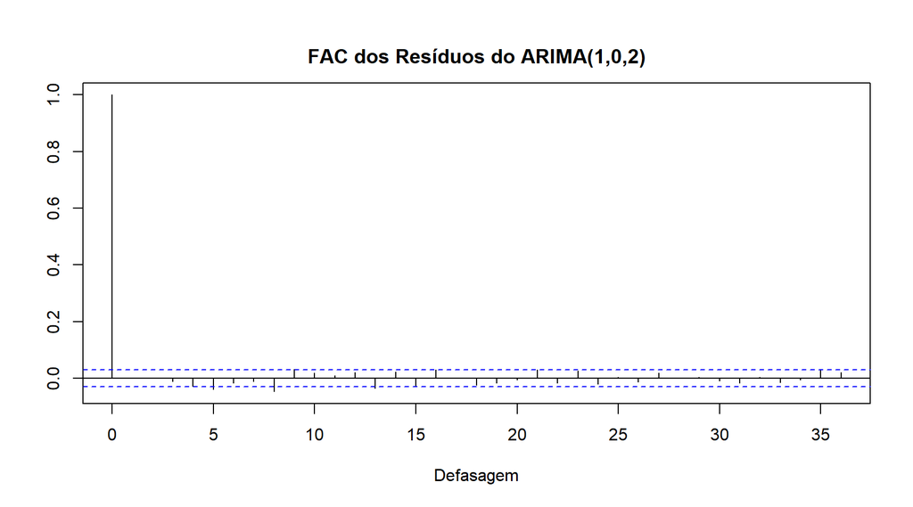

```r
Box.test(modelo_microsoft[[8]]$residuals, type = "Ljung-Box")
```

```
##
##  Box-Ljung test
##
## data:  modelo_microsoft[[8]]$residuals
## X-squared = 9.9731e-05, df = 1, p-value = 0.992
```

Ainda mais, verificando se os resíduos são normalmente distribuídos, vemos pelo histograma que ele aparenta seguir normalidade. Porém, por meio do teste de Shapiro, rejeitamos a hipótese nula do teste de que os dados são normalmente distribuídos e observando o q-q plot temos que a distribuição dos resíduos está mais ajustado para uma t-student devido as caudas pesadas.

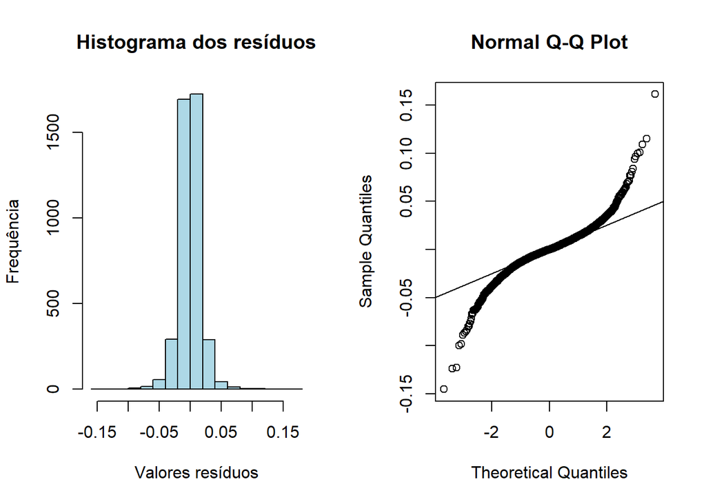

```r
op = par(mfrow = c(1, 2))
hist(modelo_microsoft[[8]]$residuals, main = "Histograma dos resíduos", col = "lightblue",
     xlab = "Valores resíduos", ylab = "Frequência")
qqnorm(modelo_microsoft[[8]]$residuals)
qqline(modelo_microsoft[[8]]$residuals)
```

```r
par(op)
```

```r
shapiro.test(modelo_microsoft[[8]]$residuals)
```

```
##
##  Shapiro-Wilk normality test
##
## data:  modelo_microsoft[[8]]$residuals
## W = 0.92448, p-value < 2.2e-16
```

Também, ao analisar a presença de heterocedasticidade condicional por meio da FAC dos resíduos ao quadrado, encontramos várias defasagens fora das bandas de confiança indicando a presença de heterocedasticidade condicional nos resíduos obtidos do modelo. Logo, precisamos utilizar modelos de heterocedasticidade condicional.

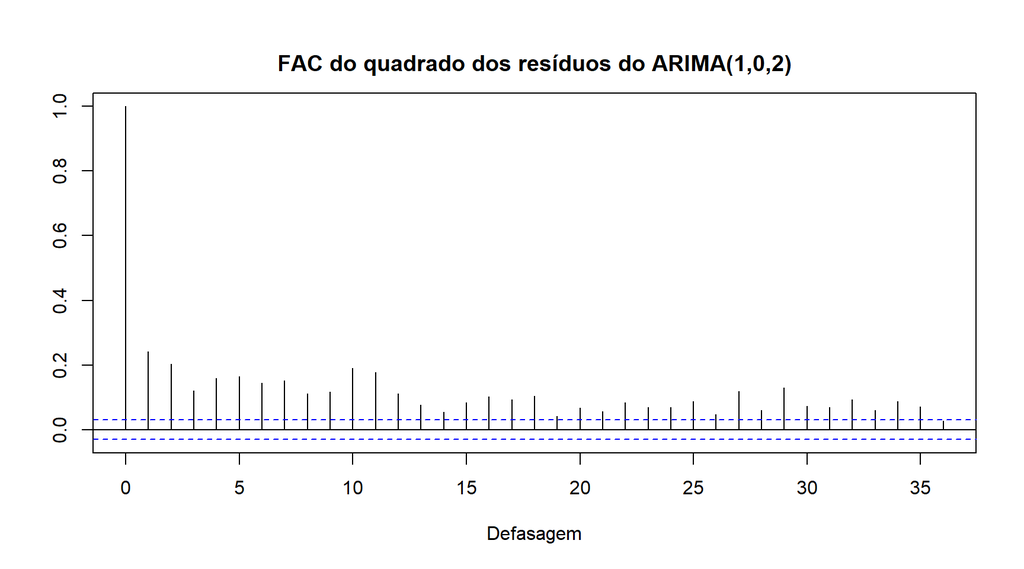

```r
Box.test(modelo_microsoft[[8]]$residuals^2, type = "Ljung-Box")
```

```
##
##  Box-Ljung test
##
## data:  modelo_microsoft[[8]]$residuals^2
## X-squared = 241.7, df = 1, p-value < 2.2e-16
```

## Modelos de heterocedasticidade condicional

Ajustando

```r
spec <- ugarchspec(mean.model = list(armaOrder = c(1, 2), include.mean = FALSE), variance.model = list(model = 'sGARCH', garchOrder = c(3, 0)), distribution = 'std')
fit_01 <- ugarchfit(spec, df$log_retorno_dif, solver = 'hybrid')
fit_01
```

```
##
## *---------------------------------*
## *          GARCH Model Fit        *
## *---------------------------------*
##
## Conditional Variance Dynamics
## -----------------------------------
## GARCH Model  : sGARCH(3,0)
## Mean Model   : ARFIMA(1,0,2)
## Distribution : std
##
## Optimal Parameters
## ------------------------------------
##         Estimate  Std. Error     t value Pr(>|t|)
## ar1    -0.977506    0.003004   -325.4503    0e+00
## ma1     0.941184    0.000001 713535.2311    0e+00
## ma2    -0.042014    0.000079   -532.7383    0e+00
## omega   0.000158    0.000011     14.5924    0e+00
## alpha1  0.228369    0.035885      6.3640    0e+00
## alpha2  0.196618    0.035020      5.6144    0e+00
## alpha3  0.153255    0.031548      4.8578    1e-06
## shape   4.056027    0.276371     14.6760    0e+00
##
## Robust Standard Errors:
##         Estimate  Std. Error     t value Pr(>|t|)
## ar1    -0.977506    0.002889   -338.3227  0.0e+00
## ma1     0.941184    0.000001 856567.1886  0.0e+00
## ma2    -0.042014    0.000042  -1005.2447  0.0e+00
## omega   0.000158    0.000014     11.4506  0.0e+00
## alpha1  0.228369    0.044470      5.1354  0.0e+00
## alpha2  0.196618    0.038111      5.1591  0.0e+00
## alpha3  0.153255    0.035285      4.3433  1.4e-05
## shape   4.056027    0.298053     13.6084  0.0e+00
##
## LogLikelihood : 11420.67
##
## Information Criteria
## ------------------------------------
##
## Akaike       -5.5107
```

[output cut: 49 more lines]

```
## Negative Sign Bias  1.1596 0.2463
## Positive Sign Bias  0.4384 0.6611
## Joint Effect        4.9165 0.1780
##
##
## Adjusted Pearson Goodness-of-Fit Test:
## ------------------------------------
##   group statistic p-value(g-1)
## 1    20     54.74    2.551e-05
## 2    30     62.56    2.933e-04
## 3    40     82.43    6.042e-05
## 4    50     75.84    8.276e-03
##
##
## Elapsed time : 1.472332
```

```r
spec <- ugarchspec(mean.model = list(armaOrder = c(1, 2), include.mean = FALSE), variance.model = list(model = 'sGARCH', garchOrder = c(4, 0)), distribution = 'std')
fit_02 <- ugarchfit(spec, df$log_retorno_dif, solver = 'hybrid')
fit_02
```

```
##
## *---------------------------------*
## *          GARCH Model Fit        *
## *---------------------------------*
##
## Conditional Variance Dynamics
## -----------------------------------
## GARCH Model  : sGARCH(4,0)
## Mean Model   : ARFIMA(1,0,2)
## Distribution : std
##
## Optimal Parameters
## ------------------------------------
##         Estimate  Std. Error  t value Pr(>|t|)
## ar1     0.708479    0.158805  4.46132 0.000008
## ma1    -0.744649    0.159496 -4.66877 0.000003
## ma2     0.010305    0.018902  0.54518 0.585628
## omega   0.000133    0.000010 13.46822 0.000000
## alpha1  0.187831    0.033050  5.68330 0.000000
## alpha2  0.173533    0.032397  5.35643 0.000000
## alpha3  0.128688    0.029906  4.30307 0.000017
## alpha4  0.169639    0.032257  5.25901 0.000000
## shape   4.207911    0.296004 14.21574 0.000000
##
## Robust Standard Errors:
##         Estimate  Std. Error  t value Pr(>|t|)
## ar1     0.708479    0.082017  8.63823 0.000000
## ma1    -0.744649    0.083586 -8.90882 0.000000
## ma2     0.010305    0.016619  0.62007 0.535215
## omega   0.000133    0.000013 10.30594 0.000000
## alpha1  0.187831    0.039163  4.79614 0.000002
## alpha2  0.173533    0.032860  5.28102 0.000000
## alpha3  0.128688    0.034260  3.75624 0.000172
## alpha4  0.169639    0.035052  4.83957 0.000001
## shape   4.207911    0.315532 13.33592 0.000000
##
## LogLikelihood : 11444.92
##
## Information Criteria
## ------------------------------------
```

[output cut: 52 more lines]

```
## Negative Sign Bias 0.82554 0.4091
## Positive Sign Bias 0.01625 0.9870
## Joint Effect       4.45713 0.2161
##
##
## Adjusted Pearson Goodness-of-Fit Test:
## ------------------------------------
##   group statistic p-value(g-1)
## 1    20     55.26    2.123e-05
## 2    30     69.81    3.223e-05
## 3    40     73.88    6.247e-04
## 4    50     86.56    7.493e-04
##
##
## Elapsed time : 1.413604
```

```r
spec <- ugarchspec(mean.model = list(armaOrder = c(1, 2), include.mean = FALSE), variance.model = list(model = 'sGARCH', garchOrder = c(5, 0)), distribution = 'std')
fit_03 <- ugarchfit(spec, df$log_retorno_dif, solver = 'hybrid')
fit_03
```

```
##
## *---------------------------------*
## *          GARCH Model Fit        *
## *---------------------------------*
##
## Conditional Variance Dynamics
## -----------------------------------
## GARCH Model  : sGARCH(5,0)
## Mean Model   : ARFIMA(1,0,2)
## Distribution : std
##
## Optimal Parameters
## ------------------------------------
##         Estimate  Std. Error     t value Pr(>|t|)
## ar1    -0.977112    0.003104   -314.7907 0.000000
## ma1     0.944214    0.000001 893505.5021 0.000000
## ma2    -0.037784    0.000062   -605.1661 0.000000
## omega   0.000118    0.000009     12.7190 0.000000
## alpha1  0.172415    0.031385      5.4935 0.000000
## alpha2  0.148248    0.030298      4.8930 0.000001
## alpha3  0.105212    0.027389      3.8413 0.000122
## alpha4  0.137545    0.030530      4.5053 0.000007
## alpha5  0.134942    0.028773      4.6898 0.000003
## shape   4.358956    0.312450     13.9509 0.000000
##
## Robust Standard Errors:
##         Estimate  Std. Error     t value Pr(>|t|)
## ar1    -0.977112    0.002901 -3.3685e+02  0.0e+00
## ma1     0.944214    0.000001  1.0482e+06  0.0e+00
## ma2    -0.037784    0.000031 -1.2272e+03  0.0e+00
## omega   0.000118    0.000013  9.3904e+00  0.0e+00
## alpha1  0.172415    0.035775  4.8194e+00  1.0e-06
## alpha2  0.148248    0.029934  4.9525e+00  1.0e-06
## alpha3  0.105212    0.031179  3.3745e+00  7.4e-04
## alpha4  0.137545    0.033085  4.1573e+00  3.2e-05
## alpha5  0.134942    0.031692  4.2579e+00  2.1e-05
## shape   4.358956    0.336902  1.2938e+01  0.0e+00
##
## LogLikelihood : 11464.65
##
```

[output cut: 55 more lines]

```
## Negative Sign Bias 0.81506 0.4151
## Positive Sign Bias 0.09098 0.9275
## Joint Effect       3.90859 0.2715
##
##
## Adjusted Pearson Goodness-of-Fit Test:
## ------------------------------------
##   group statistic p-value(g-1)
## 1    20     41.21     0.002265
## 2    30     56.59     0.001606
## 3    40     69.99     0.001681
## 4    50     66.38     0.049669
##
##
## Elapsed time : 1.520345
```

```r
spec <- ugarchspec(mean.model = list(armaOrder = c(1, 2), include.mean = FALSE), variance.model = list(model = 'sGARCH', garchOrder = c(6, 0)), distribution = 'std')
fit_04 <- ugarchfit(spec, df$log_retorno_dif, solver = 'hybrid')
fit_04
```

```
##
## *---------------------------------*
## *          GARCH Model Fit        *
## *---------------------------------*
##
## Conditional Variance Dynamics
## -----------------------------------
## GARCH Model  : sGARCH(6,0)
## Mean Model   : ARFIMA(1,0,2)
## Distribution : std
##
## Optimal Parameters
## ------------------------------------
##         Estimate  Std. Error  t value Pr(>|t|)
## ar1    -0.475213    0.933213 -0.50922 0.610596
## ma1     0.438167    0.932629  0.46982 0.638484
## ma2    -0.027188    0.023947 -1.13534 0.256234
## omega   0.000106    0.000009 11.76472 0.000000
## alpha1  0.146312    0.029615  4.94053 0.000001
## alpha2  0.136023    0.029255  4.64952 0.000003
## alpha3  0.098970    0.026797  3.69328 0.000221
## alpha4  0.127528    0.030586  4.16956 0.000031
## alpha5  0.118754    0.028393  4.18248 0.000029
## alpha6  0.108103    0.027235  3.96931 0.000072
## shape   4.413614    0.318246 13.86857 0.000000
##
## Robust Standard Errors:
##         Estimate  Std. Error  t value Pr(>|t|)
## ar1    -0.475213    0.777749 -0.61101 0.541193
## ma1     0.438167    0.779424  0.56217 0.574001
## ma2    -0.027188    0.029036 -0.93637 0.349082
## omega   0.000106    0.000012  8.80643 0.000000
## alpha1  0.146312    0.032826  4.45713 0.000008
## alpha2  0.136023    0.028824  4.71917 0.000002
## alpha3  0.098970    0.029250  3.38355 0.000716
## alpha4  0.127528    0.033705  3.78367 0.000155
## alpha5  0.118754    0.031571  3.76145 0.000169
## alpha6  0.108103    0.027294  3.96068 0.000075
## shape   4.413614    0.340759 12.95230 0.000000
##
```

[output cut: 58 more lines]

```
## Negative Sign Bias 1.01333 0.3110
## Positive Sign Bias 0.02743 0.9781
## Joint Effect       3.95641 0.2662
##
##
## Adjusted Pearson Goodness-of-Fit Test:
## ------------------------------------
##   group statistic p-value(g-1)
## 1    20     37.89    0.0061221
## 2    30     61.69    0.0003784
## 3    40     70.50    0.0014833
## 4    50     75.70    0.0085271
##
##
## Elapsed time : 1.268117
```

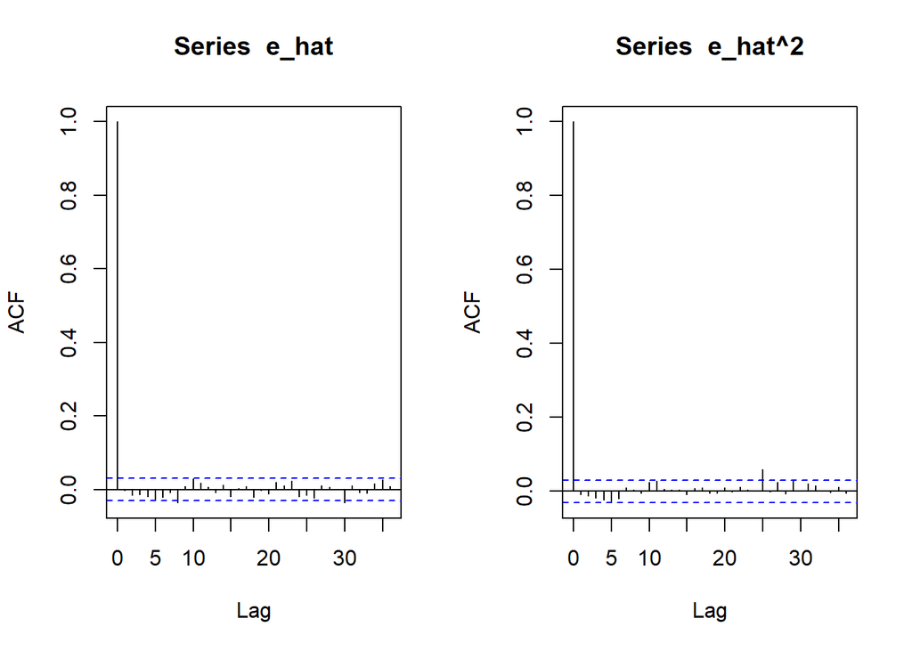

```r
e_hat = fit_04@fit$residuals/fit_04@fit$sigma
op = par(mfrow = c(1,2))
acf(e_hat)
acf(e_hat^2)
```

```r
par(op)
```

```r
# fore_05 = ugarchforecast(fit_05, n.ahead = 5)
# fore_05
```

```r
# teste = forecast(modelo_microsoft[[8]])
# modelo_microsoft[[8]]
```